# 2-Simple_Regression_Model

Author: Rick Dean

Article date: 2021-04-29

Abstract

The following notes and scripts are based on the following sources: [Introductory Econometrics - A Modern Approach](https://www.amazon.com/Introductory-Econometrics-Modern-Approach-Standalone/dp/130527010X/ref=sr_1_2?dchild=1&keywords=Introductory+Econometrics%3A+A+Modern+Approach&qid=1597005903&s=books&sr=1-2) by Jeffrey M. Wooldridge is the main text for the statistical content. This text will be referenced as `(Wooldridge)`.

The companion text [Using R for Introductory Econometrics](http://www.urfie.net/index.html) by Florian Heiss provides specific R scripts in support of the main text and the inspiration for my scripts, notes and graphics. I will reference this document as `(Heiss)`. The following is from **Part 1 - Regression Analysis with Cross-Sectional Data, Chapter 2 The simple Regression Model** of `(Heiss)`.

```r
library(knitr)
library(data.table)
library(wooldridge)
library(ggplot2)
library(RregressPkg)
library(RplotterPkg)
```

# 2 The Simple Regression Model

## 2.1 Simple OLS Regression

We want to estimate the population parameters $\hat{\beta_{0}}$ and $\hat{\beta_{1}}$ of the simple regression model:

$\hat{y_{i}} = \hat{\beta_{0}} + \hat{\beta_{1}}x_{i}$[2.20 Wooldridge page 27]

where $\hat{y_{i}}$ is the **fitted value** for $y$ at observation $i$.

According to `(Wooldridge, Section 2.2, Equations 2.17, 2.19, page 26)` we can estimate the OLS regression line with:

$\hat{\beta_{0}} = \bar{y} - \hat{\beta_{1}}\bar{x}$[2.2 Heiss page 69]

$\hat{\beta_{1}} = \frac{Cov(x,y)}{Var(x)}$[2.3 Heiss page 69]

Task: From the `wooldridge::ceosal1` data set involving “CEO Salary” (*salary*) and “Return on Equity” (*roe*) calculate the statistics for estimating the population parameters $\beta_{0}$ and $\beta_{1}$ for the *roe* variable to estimate *salary*.

In the “pedestrian” approach to estimating $\hat{\beta_{0}}$ and $\hat{\beta_{1}}$ both Heiss (in Equations 2.2 and 2.3) and Wooldridge (in Equations 2.17 and 2.19) point out that we “just need to calculate the four statistics $\bar{y}$, $\bar{x}$, $Cov(x,y)$, and $Var(x)$”.

1. Read the data set:

```r
data(ceosal1, package = "wooldridge")
ceosal1_dt <- data.table::setDT(ceosal1)
ceosal1_dt <- ceosal1_dt[, .(roe, salary)]
```

2. From `(Wooldridge, Equation 2.19 page 26)` use the “pedestrian” approach to estimate $\hat{\beta}_1$ where we need the Cov(*roe*,*salary*) and the Var(*roe*):

```r
cov_roe_salary <- stats::cov(ceosal1_dt$roe, ceosal1_dt$salary)
var_roe <- stats::var(ceosal1_dt$roe)
b1_hat <- cov_roe_salary/var_roe
```

$Cov(salary,roe)$ = 1342.538398

$Var(roe)$ = 72.5649898

$\hat{\beta}_1 = \frac{Cov(salary,roe)}{Var(roe)}$ = 18.5011863

3. From `(Wooldridge, Equation 2.17 page 26)` estimate $\hat{\beta}_0$ where we need the means for *roe* ($\bar{x}$) and *salary* ($\bar{y}$) and our just computed $\hat{\beta}_1$:

```r
b0_hat <- mean(ceosal1_dt$salary) - b1_hat * mean(ceosal1_dt$roe)
```

$\hat{\beta}_0 = \bar{y} - \hat{\beta_{1}}\bar{x} =$ 963.1913365

Task: Use `stats::lm()` to repeat the above estimate of the coefficients $\hat{\beta_{0}}$ and $\hat{\beta_{1}}$, regressing *salary* on *roe* and plot the linear fit.

1. Compute the coefficients via `stats::lm()`:

```r
roe_salary_lm <- stats::lm(salary ~ roe, data = ceosal1_dt)
```

Coefficients from `stats::lm()`: 963.1913365, 18.5011863

2. Plot the linear fit:

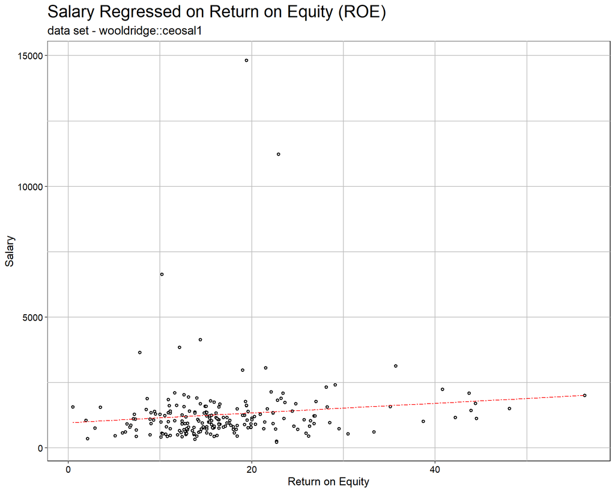

```r
df <- data.frame(
  roe = ceosal1_dt$roe,
  salary = ceosal1_dt$salary,
  fit = roe_salary_lm$fitted.values
)
RplotterPkg::create_scatter_plot(
  df = df,
  aes_x = "roe",
  aes_y = "salary",
  title = "Salary Regressed on Return on Equity (ROE)",
  subtitle = "data set - wooldridge::ceosal1",
  x_title = "Return on Equity",
  y_title = "Salary",
  rot_y_tic_label = TRUE
) + geom_line(aes(y = fit), color = "red", linetype = "twodash")
```

Wooldridge brings up another form of estimating $\beta_{1}$:

$$\hat{\beta}_{1} = \hat{\rho}_{xy} \cdot \left (\frac{\hat{\sigma}_{y}}{\hat{\sigma}_{x}}\right )$$
where $\hat{\rho}_{xy}$ is the simple correlation between $x_{i}$ and $y_{i}$ and $\hat{\sigma}_{y}$ and $\hat{\sigma}_{x}$ are the sample standard deviations. Wooldridge brings up an important point in regard to this estimate:

> Recognition that $\beta_{i}$ is just a scaled version , $\rho_{xy}$, highlights an important limitation of simple regression when we do not have experimental data: In effect, simple regression is an analysis of correlation between two variables, and so one must be careful in inferring causality.

Illustrating this second form:

```r
cor_salary_roe <- stats::cor(ceosal1_dt$salary,ceosal1_dt$roe)
salary_sd <- stats::sd(ceosal1_dt$salary)
roe_sd <- stats::sd(ceosal1_dt$roe)

b1_hat_salary_roe <- cor_salary_roe * salary_sd / roe_sd
```

$\hat{\beta_{1}}$ = 18.5011863

Take Away: Both forms of estimating $\hat{\beta_{1}}$ are equal and is a scaled version of the correlation between $x_{i}$ and $y_{i}$.

Task: Find the relationship between wage and education `(Wooldridge, Example 2.4, page 30)` from the data set `wooldridge::wage1`.

1. Read the data set:

```r
data(wage1, package = "wooldridge")
wage1_dt <- data.table::setDT(wage1)
wage1_dt <- wage1_dt[, .(wage, educ)]
```

2. Compute the OLS between *wage* and *educ*:

```r
wage_educ_lm <- stats::lm(wage ~ educ, data = wage1_dt)
```

The estimated $\hat{\beta}_0$ and $\hat{\beta}_1$ of the linear model are -0.9048516, 0.5413593

`(Wooldridge, page 30)` notes that $\hat{\beta}_1$ implies that one year of education increases hourly wage by 54 cents an hour.

3. Plot the line fit for *wage* regressed on *education*:

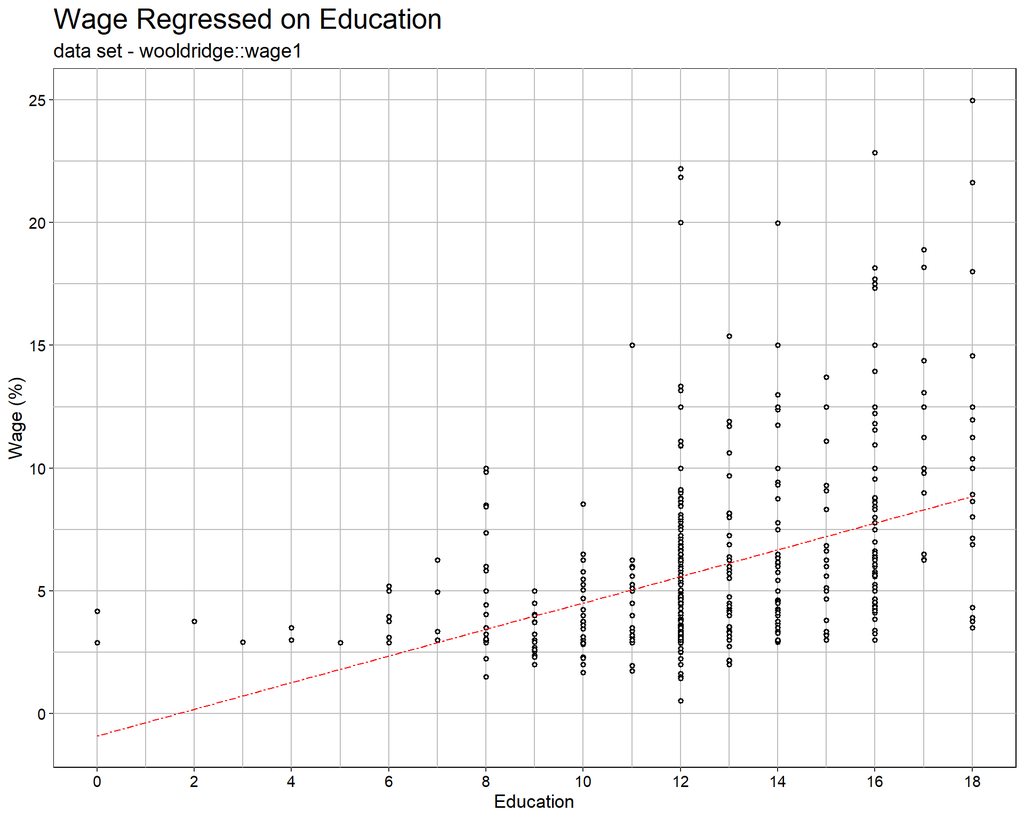

```r
df <- data.frame(
  educ = wage1_dt$educ,
  wage = wage1_dt$wage,
  fit = wage_educ_lm$fitted.values
)
RplotterPkg::create_scatter_plot(
  df = df,
  aes_x = "educ",
  aes_y = "wage",
  title = "Wage Regressed on Education",
  subtitle = "data set - wooldridge::wage1",
  x_title = "Education",
  y_title = "Wage (%)",
  rot_y_tic_label = TRUE,
  x_limits = c(0,18),
  x_major_breaks = seq(0,18,2)
) + geom_line(aes(y = fit), color = "red", linetype = "twodash")
```

## 2.2 Coeffcients, Fitted Values, and Residuals

The **residual** for observation $i$ is the difference between the actual $y_{i}$ and its fitted value:

$\hat{\mu_{i}} = y_{i} - \hat{y_{i}} = y_{i} - \hat{\beta_{0}} + \hat{\beta_{1}}x_{i}$[2.21 Wooldridge page 27]

or [Heiss] rearranges to give:

$y_{i} = \hat{\beta_{0}} + \hat{\beta_{1}}x + \hat{\mu_{i}}$[2.1 Heiss page 69]

We also have the population model for $y_{i}$:

$y_{i} = \beta_{0} + \beta_{1}x + \mu_{i}$[2.48 Wooldridge page 41]

where $\mu_{i}$ are known as the **errors** for observation $i$ where the model does not account for other predictors that may be important.

`(Wooldridge, Section 2-5c, page 48)` shows the distinction between **residual** and **errors** by deriving:

$\hat{\mu_{i}} = \mu_{i} - (\hat{\beta_{0}} - \beta{_{0}}) - (\hat{\beta_{1}} - \beta_{1})x_{i}$[2.59 Wooldridge page 49]

Thus **residuals** $\hat{\mu_{i}}$ is not the same as $\mu_{i}$. Wooldridge goes on to say that the expected difference between **residuals** and **errors** is zero and the estimate of $\mu_{i}$ is the OLS residual values $\hat{\mu_{i}}$

The population error $\mu$ and its estimate also have a variance known as the **error variance** $\sigma^{2}$ where its square root is the standard deviation of the error. `(Wooldridge, page 45)` notes that a larger $\sigma$ means that the distribution of the unobservables affecting $y$ is more spread out.

`(Wooldridge Theorem 2.2 page 47)` derives the variance of the OLS estimator $VAR(\hat{\beta_{1}})$ where $\sigma^2$ plays a central role. See section 2.6 below.

`(Wooldridge, Section 2-3b, page 32)` presents three properties of OLS statistics. The three properties `(Heiss, page 76)`are:

1. Sum and sample mean of the **residuals**:

$\sum_{i=1}^n \hat{\mu_{i}} = 0 \Rightarrow \bar{\hat{\mu}}_{i} = 0$[2.7 Heiss page 76]

2. Sample covariance between the regressors and the OLS residuals:

$\sum_{i=1}^n x_{i}\hat{\mu}_{i} = 0$ $\Rightarrow$ $Cov(x_{i}, \hat{\mu}_{i}) = 0$[2.8 Heiss page 76]

3. The mean is always on the line:

$\bar{y} = \hat{\beta}_0 + \hat{\beta}_1 \cdot \bar{x}$[2.9 Heiss page 76]

Task: Take the above wage and education data set and confirm the three properties of OLS.

1. Property 1 – Mean of the residuals $\hat{\mu_{i}}$ = 0:

```r
mu_hat <- stats::resid(wage_educ_lm)
mu_hat_mean <- mean(mu_hat)
```

Mean of $\hat{\mu_{i}}$ = -1.1949804^{-16}

2. Property 2 – The sample covariance between the predictors and the OLS residuals is zero. $Cov(x_{i},\hat{\mu}_{i}) = 0$

```r
cov_x_mu <- stats::cov(wage1_dt$educ, mu_hat)
```

Cov of $Cov(x_{i},\hat{\mu}_{i})$ = 4.0650626^{-15}

3. Property 3 – The point $(\bar{x},\bar{y})$ is always on the OLS regression line. $\bar{y} = \hat{\beta_{0}} + \hat{\beta_{1}} * \bar{x}$

```r
y_mean <- mean(wage1_dt$wage)
```

The $\bar{y}$ = 5.8961027

```r
lm_coef <- coef(wage_educ_lm)
y_mean_lm <- lm_coef[1] + lm_coef[2] * mean(wage1_dt$educ)
```

$\hat{\beta_{0}} + \hat{\beta_{1}} * \bar{x}$ = 5.8961027

## 2.3 Goodness of fit

Task: Using the above data of *salary* on *roe* compute the $R^2$ or coefficient of determination three different ways where `(Wooldridge, Equations 2.33,2.34,2.35 page 34)` defines:.

Total sum of the squares (SST) = $\sum_{i=1}^n(y_{i} - \bar{y})^2 = (n - 1) \cdot Var(y)$[2.10 Heiss page 77]

Explained sum of the squares (SSE) = $\sum_{i=1}^n(\hat{y}_{i} - \bar{y})^2 = (n - 1) \cdot Var(\hat{y})$[2.11 Heiss page 77]

Residual sum of the squares (SSR) = $\sum_{i=1}^n(\hat{\mu}_{i} - 0)^2 = (n - 1) \cdot Var(\hat{\mu})$[2.12 Heiss page 77]

`(Wooldridge, Equation 2.38, page 35)` defines
$$R^2 = \frac{SSE}{SST} = 1 - \frac{SSR}{SST}$$
or
$$R^2 = \frac{Var(\hat{y})}{Var(y)} = 1 - \frac{Var(\hat{\mu})}{Var(y)}$$

1. Compute the SST, SSE, SSR:

```r
n <- nrow(ceosal1_dt)
SST <- (n - 1) * stats::var(ceosal1_dt$salary)
SSE <- (n - 1) * stats::var(fitted(roe_salary_lm))
SSR <- (n - 1) * stats::var(resid(roe_salary_lm))
```

$SST = (n - 1) \cdot Var(y)$ = 3.9173298^{8}

$SSE = (n - 1) \cdot Var(\hat{y})$ = 5.166419^{6}

$SSR = (n - 1) \cdot Var(\hat{\mu})$ = 3.8656656^{8}

2. Compute $R^2$ via $Var(\hat{y})/Var(y)$:

```r
R_2_1 <- SSE/SST
```

$Var(\hat{y})/Var(y)$ = 0.0131886

3. Compute $R^2$ via $1 - Var(\hat{\mu})/Var(y)$

```r
R_2_2 <- 1 - (SSR/SST)
```

$1 - Var(\hat{\mu})/Var(y)$ = 0.0131886

4. Compute $R^2$ using `stats::cor()` function:

```r
R_2_3 <- stats::cor(ceosal1_dt$salary, fitted(roe_salary_lm))^2
```

`stats::cor()` = 0.0131886

The `stats::summary()` function can also show us the $R^2$ value as “Multiple R-squared”:

```r
stats::summary.lm(roe_salary_lm)
```

```
##
## Call:
## stats::lm(formula = salary ~ roe, data = ceosal1_dt)
##
## Residuals:
##     Min      1Q  Median      3Q     Max
## -1160.2  -526.0  -254.0   138.8 13499.9
##
## Coefficients:
##             Estimate Std. Error t value Pr(>|t|)
## (Intercept)   963.19     213.24   4.517 1.05e-05 ***
## roe            18.50      11.12   1.663   0.0978 .
## ---
## Signif. codes:  0 '***' 0.001 '**' 0.01 '*' 0.05 '.' 0.1 ' ' 1
##
## Residual standard error: 1367 on 207 degrees of freedom
## Multiple R-squared:  0.01319,    Adjusted R-squared:  0.008421
## F-statistic: 2.767 on 1 and 207 DF,  p-value: 0.09777
```

## 2.4 Nonlinearities

According to `(Wooldridge, page 37)` “…it is rather easy to incorporate many non-linearities into simple regression analysis by appropriately defining the dependent and independent variables” (i.e. a variable transformation).

In taking the above example of *wage* regressed on *education* suppose we believe that each year of education increases wage by a constant **percentage**. The percentage of wage change for one unit of education is the same at any starting value for years of education. A model that gives a constant percentage effect is:

$log(wage) = \beta_{0} + \beta_{1}educ + \mu$[2.42 Wooldridge page 37]

Task: Using equation [2.42] estimate the linear model of `log(wage)` (i.e. the natural log of *wage*) regressed on *educ*.

```r
log_wage_educ_lm <- stats::lm(log(wage) ~ educ, data = wage1_dt)
b0 <- coef(log_wage_educ_lm)[[1]]
b1 <- coef(log_wage_educ_lm)[[2]]
```

The regression of `log(wage)` on education is:
$$\widehat{log(wage)} = 0.584 + 0.083 \cdot educ$$
The model’s estimate for $\hat{\beta}_{1}$ is 0.083 or multiplying by 100 we can say that $\widehat{log(wage)}$ increases by 8.3% for every additional year of education.

Task: Exponentiate equation [2.42] and plot the nonlinear nature of how *wage* increases for every additional year of education.

1. By exponentiating [2.42], we can write an equation involving just *wage* and *educ*:
   $$\widehat{wage} = exp(\hat{\beta_{0}} + \hat{\beta_{1}}educ + \hat{\mu)}$$

```r
educ <- seq(0, 19, 1)
log_wage <- b0 + b1 * educ
wage <- exp(log_wage)
wage_exp_dt <- data.table(
  educ = educ,
  wage = wage
)
head(wage_exp_dt)
```

```
##    educ     wage
## 1:    0 1.792789
## 2:    1 1.947443
## 3:    2 2.115437
## 4:    3 2.297923
## 5:    4 2.496151
## 6:    5 2.711480
```

2. Plot *wage* vs *educ*:

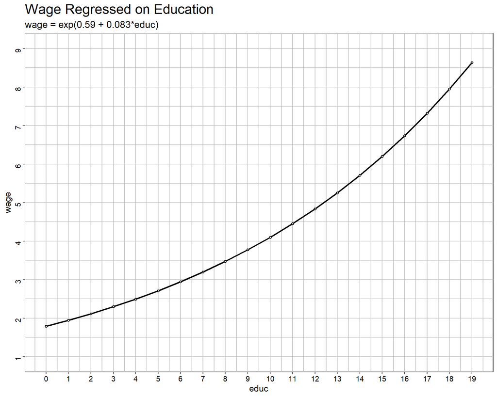

```r
RplotterPkg::create_scatter_plot(
  df = wage_exp_dt,
  aes_x = "educ",
  aes_y = "wage",
  title = "Wage Regressed on Education",
  subtitle = "wage = exp(0.59 + 0.083*educ)",
  connect = TRUE,
  x_limits = c(0,19),
  x_major_breaks = seq(0,19,1),
  y_limits = c(1,9),
  y_major_breaks = seq(1,9,1)
)
```

## 2.5 Regression through the Origin and Regression on a Constant

`(Wooldridge, Section 2-6, page 50)` discusses models without an intercept.

Task: Using the above data of *salary* on *roe* compute the model $\hat{y} = \hat{\beta}_{1} \cdot x$ (i.e. regression is through the origin; in the OLS model use 0 for the intercept value).

```r
roe_salary_no_intercept_lm <- stats::lm(formula = salary ~ 0 + roe, data = ceosal1_dt)
```

$\hat{\beta}_{1} =$ 63.5379552

Task: Using the above data of *salary* on *roe* compute the model $\hat{y} = \hat{\beta}_{0}$ (i.e. the regression is a constant).

```r
roe_salary_constant_lm <- stats::lm(formula = salary ~ 1, data = ceosal1_dt)
```

$\hat{\beta}_{0} =$ 1281.1196172

```r
df_obser <- data.frame(
  roe = ceosal1_dt$roe,
  salary = ceosal1_dt$salary,
  type = "Observations"
)
df_no_intercept <- data.frame(
  roe = ceosal1_dt$roe,
  salary = roe_salary_no_intercept_lm$fitted.values,
  type = "No Intercept"
)
df_constant <- data.frame(
  roe = ceosal1_dt$roe,
  salary = roe_salary_constant_lm$fitted.values,
  type = "Constant"
)
```

2. Plot the data:

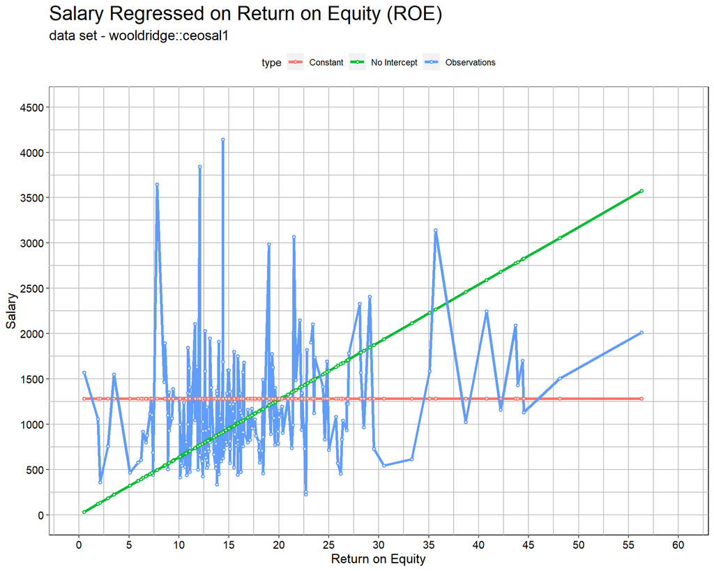

```r
df <- rbind(df_obser,df_no_intercept,df_constant)
RplotterPkg::create_scatter_plot(
  df = df,
  aes_x = "roe",
  aes_y = "salary",
  aes_color = "type",
  title = "Salary Regressed on Return on Equity (ROE)",
  subtitle = "data set - wooldridge::ceosal1",
  x_title = "Return on Equity",
  y_title = "Salary",
  rot_y_tic_label = TRUE,
  line_size = 1.4,
  x_limits = c(0,60),
  x_major_breaks = seq(0,60,5),
  y_limits = c(0,4500),
  y_major_breaks = seq(0,4500,500),
  connect = T
)
```

## 2.6 Expected Values, Variances, and Standard Errors

`(Wooldridge, Section 2-5b, page 45)` presents Theorem 2.2 on the sampling variances of the OLS estimators $\hat{\beta}_{0}$ and $\hat{\beta}_{1}$. `(Heiss, page 82)` gives the following equivalent formulas:

$se(\hat{\beta}_{0}) = \frac{1}{\sqrt{n-1}}\cdot\frac{\hat{\sigma}}{sd(x)}\cdot\sqrt{\bar{x^2}}$[2.15 Heiss page 82]

$se(\hat{\beta}_{1}) = \frac{1}{\sqrt{n-1}}\cdot\frac{\hat{\sigma}}{sd(x)}$[2.16 Heiss page 82]

where $\hat{\sigma}^2 = \frac{n-1}{n-2}\cdot Var(\hat{\mu}_{i})$ is the variance of the error term $\mu$. $\hat{\sigma}$ = $\sqrt{\hat{\sigma}^2}$ is known as the **standard error of the regression** (SER) or **residual standard error**

Task: Using the data set `Wooldridge::meap93`, compute the standard errors of the OLS estimators using the above equations.

Note that from the data set we are regressing math performance scores of schools on the share of students eligible for a federally funded lunch program.

1. Read the data set:

```r
data("meap93", package = "wooldridge")
meap93_dt <- data.table::setDT(meap93)
meap93_dt <- meap93_dt[, .(math10, lnchprg)]
```

2. Estimate the OLS model:

```r
math_lunch_lm <- stats::lm(formula = math10 ~ lnchprg, data = meap93_dt)
```

3. Compute the **residual standard error** (SER):

```r
n = nrow(meap93_dt)
SER <- sd(resid(math_lunch_lm)) * sqrt((n-1)/(n-2))
```

The *SER* = 9.5659385

4. Compute the standard errors for $\hat{\beta}_{0}$ and $\hat{\beta}_{1}$:

```r
beta_0_se <- (SER/sd(meap93_dt$lnchprg))/sqrt(n-1) * sqrt(mean(meap93_dt$lnchprg^2))
beta_1_se <- (SER/sd(meap93_dt$lnchprg))/sqrt(n-1)
```

$se(\hat{\beta}_{0}) =$ 0.9975824 $se(\hat{\beta}_{1}) =$ 0.0348393

5. Compare the standard error values with those estimated from automatic calculations:

```r
summary(math_lunch_lm)
```

```
##
## Call:
## stats::lm(formula = math10 ~ lnchprg, data = meap93_dt)
##
## Residuals:
##     Min      1Q  Median      3Q     Max
## -24.386  -5.979  -1.207   4.865  45.845
##
## Coefficients:
##             Estimate Std. Error t value Pr(>|t|)
## (Intercept) 32.14271    0.99758  32.221   <2e-16 ***
## lnchprg     -0.31886    0.03484  -9.152   <2e-16 ***
## ---
## Signif. codes:  0 '***' 0.001 '**' 0.01 '*' 0.05 '.' 0.1 ' ' 1
##
## Residual standard error: 9.566 on 406 degrees of freedom
## Multiple R-squared:  0.171,  Adjusted R-squared:  0.169
## F-statistic: 83.77 on 1 and 406 DF,  p-value: < 2.2e-16
```

## 2.7 Monto Carlo Simulations

### 2.7.1 One sample

Task: We are given population coefficients for $\beta_{0}$ = 1, $\beta_{1}$ = 0.5, and set the sd of the error term $\mu$ to $\sigma$ = 2. If we draw a random sample ($n$ = 1000) of the independent variable $x$, then the population $y$ values can be computed from the population coefficients. If we estimate the coefficients via OLS, using $x$ and $y$ as input, how does the estimated $\hat{y}$ compare with the population $y$ values.

1. Set the seed, set the population parameters, and draw a random sample of $x$ with mean = 4 and sd = 1:

```r
set.seed(1234567)
n <-  1000
b_0 <- 1
b_1 <- 0.5
x <- stats::rnorm(n, 4, 1)
```

2. Draw a random sample of the error term $\mu$ which has a mean of 0 and sd of 2:

```r
mu <- stats::rnorm(n, 0, 2)
```

3. Compute the population $y$ values:

```r
y <- b_0 + b_1 * x + mu
```

4. Estimate the coefficients via OLS:

```r
model_lm <- stats::lm(y ~ x)
```

The estimated coefficients via OLS are: 1.2091716, 0.4384287

5. Plot both the population $y$ and the $\hat{y}$ estimated from OLS:

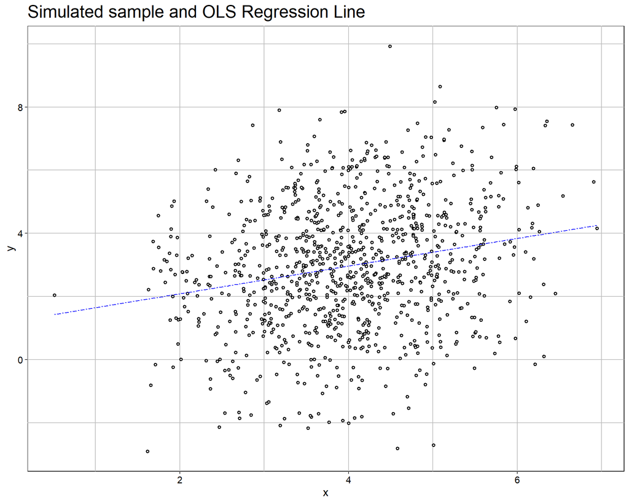

```r
dt <- data.table(
  x = x,
  y = y,
  fit = model_lm$fitted.values
)

RplotterPkg::create_scatter_plot(
  df = dt,
  aes_x = "x",
  aes_y = "y",
  title = "Simulated sample and OLS Regression Line",
  rot_y_tic_label = TRUE
) + geom_line(aes(y = fit), color = "blue", linetype = "twodash")
```

Task: Compute the standard errors of the above $\hat{\beta_{0}}$ and $\hat{\beta_{1}}$ OLS estimates.

`(Wooldridge, Theorem 2.2, page 47)` states that the standard errors involve the mean values of $x^2$ ($\bar{x^2}$) and sum of the squares $\sum^n_{i=1}(x-\bar{x})^2$ where:
$$Var(\beta_{0}) = \frac{\sigma^2 \bar{x^2}}{\sum^n_{i=1}(x-\bar{x})^2}$$
$$Var(\beta_{1}) = \frac{\sigma^2}{\sum^n_{i=1}(x-\bar{x})^2}$$

1. Compute mean($x^2$)

```r
x_2_mean <- mean(x^2)
```

The mean of $x^2$ = 16.9664407

2. Compute $\sum^n_{i=1}(x-\bar{x})^2$

```r
x_sum_2 <- sum((x - mean(x))^2)
```

$\sum^n_{i=1}(x-\bar{x})^2$ = 990.4103944

Standard error of $\hat{\beta_{0}}$ = 0.2617687

Standard error of $\hat{\beta_{1}}$ = 0.063551

## 2.7.2 Many samples

Task: Repeat the simulation in the above section by computing a random set of $x$ values along with 10000 random normal sets of the error term $\mu$

1. Set the seed, set the population parameters, and draw a random sample of $x$ with mean = 4 and sd = 1:

```r
set.seed(1234567)
n <-  1000
simulations_n <- 10000
b_0 <- 1
b_1 <- 0.5
sd_mu <- 2
x <- stats::rnorm(n, 4, 1)
# initialize vectors for storing OLS coefficient estimates
b_0_ols <- numeric(simulations_n)
b_1_ols <- numeric(simulations_n)
```

2. Repeat the simulation 10000 times and store the estimated OLS coefficients:

```r
for(j in 1:10000){
  # draw a sample of y
  mu <- stats::rnorm(n, mean = 0, sd = sd_mu)
  y <- b_0 + b_1 * x + mu

  # estimate coefficients by OLS and store them in the vectors
  b_ols <- stats::coefficients(lm(y~x))
  b_0_ols[j] <- b_ols["(Intercept)"]
  b_1_ols[j] <- b_ols["x"]
}
```

3. Compute the means of the 10000 estimated OLS coefficients noting that $\beta_{0}$ = 1 and $\beta_{1}$ = 0.5: E($\hat{\beta}_{0}$) = 0.9985388

E($\hat{\beta}_{1}$) = 0.5000466

4. Compute the standard error of the sampled estimated OLS coefficients:

```r
sample_b_0_se = sqrt(var(b_0_ols))
sample_b_1_se = sqrt(var(b_1_ols))
```

sampled_se($\beta_{0}$) = 0.262837

sampled_se($\beta_{1}$) = 0.0637892

5. compare the sample coefficient standard errors to `(Heiss, equations 2.15, 2.16, page 82)`

```r
b_0_se = (1/sqrt(n-1))*(2/sd(x))*sqrt(mean(x^2))
b_1_se = (1/sqrt(n-1))*(2/sd(x))
```

se($\beta_{0}$) = 0.2617687

se($\beta_{1}$) = 0.063551

6. Plot the OLS fits:

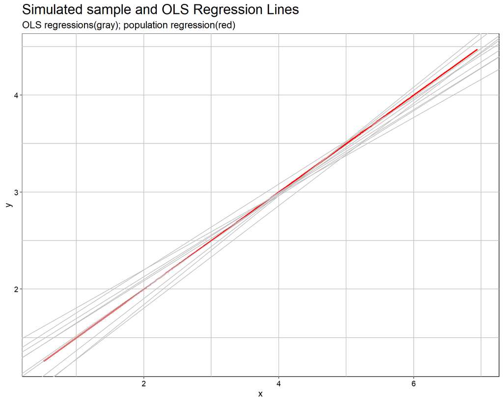

```r
pop_df <- data.frame(
  x = x,
  y = b_0 + b_1 * x
)
ols_plot <- RplotterPkg::create_scatter_plot(
 df = pop_df,
 aes_x = "x",
 aes_y = "y",
 title = "Simulated sample and OLS Regression Lines",
 subtitle = "OLS regressions(gray); population regression(red)",
 connect = T,
 rot_y_tic_label = T,
 show_pts = F,
 line_color = "red"
)
for(i in 1:10){
  ols_plot <- ols_plot + ggplot2::geom_abline(intercept = b_0_ols[i], slope = b_1_ols[i], color = "gray")
}
ols_plot
```

### 2.7.3 Violation of SLR.4

`(Wooldridge, section 2-5, page 40)` presents set of assumptions for simple linear regression (SLR). He outlines 5 assumptions (SLR.1 - SLR.5). `(Heiss, page 82)` list these assumptions and considers the violation of SLR.4 $E(\mu_{i}|x_{i}) = 0$ (zero conditional mean).

Task: Repeat the many sample Monte Carlo simulation in the above section 2.7.2 and compute a randomly selected population $\mu$ where the $\mu$’s mean is conditional on $x$. For example set $E(\mu_{i}|x_{i}) = \frac{x_{i}-4}{5}$

1. Set the seed, set the population parameters, and draw a random sample of $x$ with mean = 4 and sd = 1:

```r
set.seed(1234567)
n <-  1000
simulations_n <- 10000
b_0 <- 1
b_1 <- 0.5
sd_mu <- 2
x <- stats::rnorm(n, mean = 4, sd = 1)
# initialize vectors for storing OLS coefficient estimates
b_0_ols <- numeric(simulations_n)
b_1_ols <- numeric(simulations_n)
```

2. For $\mu$ set the vector of means $\frac{(x_{i}-4)}{5}$ and sd = *sd_mu* and repeat the simulation 10000 times and store the estimated OLS coefficients:

```r
for(j in 1:10000){
  # draw a sample of y
  mu <- stats::rnorm(n, mean = (x-4)/5, sd = sd_mu)
  y <- b_0 + b_1 * x + mu

  # estimate coefficients by OLS and store them in the vectors
  b_ols <- stats::coefficients(lm(y~x))
  b_0_ols[j] <- b_ols["(Intercept)"]
  b_1_ols[j] <- b_ols["x"]
}
```

3. Compute the means of the 10000 sampled estimated OLS coefficients noting that $\beta_{0}$ = 1 and $\beta_{1}$ = 0.5:

E($\hat{\beta}_{0}$) = 0.1985388

E($\hat{\beta}_{1}$) = 0.7000466

4. Compute the standard error of the sampled estimated OLS coefficients:

```r
sample_b_0_se = sqrt(var(b_0_ols))

sample_b_1_se = sqrt(var(b_1_ols))
```

sampled_se($\hat{\beta}_{0}$) = 0.262837

sampled_se($\hat{\beta}_{1}$) = 0.0637892

### 2.7.4 Violation of SLR.5

SLR.5 addresses homoscedasticity of $\mu$ where $Var(\mu_{i}|x{i}) = \sigma^2$.

Task: As an example of the SLR.5 violation, repeat the many sample Monte Carlo simulation in the above section 2.7.2 and set $Var(\mu_{i}|x_{i}) = \frac{4}{e^{4.5}}\cdot e^{x_{i}}$

1. Set the seed, set the population parameters, and draw a random sample of $x$ with mean = 4 and sd = 1:

```r
set.seed(1234567)
n <-  1000
simulations_n <- 10000
b_0 <- 1
b_1 <- 0.5
x <- stats::rnorm(n, mean = 4, sd = 1)
# initialize vectors for storing OLS coefficient estimates
b_0_ols <- numeric(simulations_n)
b_1_ols <- numeric(simulations_n)
mu_var <- numeric(simulations_n)
```

2. For $\mu$ set the vector of means to 0 and $sd(\mu_{i})$ = $sqrt(\frac{4}{e^{4.5}}\cdot e^{x_{i}})$ and repeat the simulation 10000 times and store the estimated OLS coefficients:

```r
for(j in 1:10000){
  # draw a sample of y
  mu <- stats::rnorm(n, mean = 0, sd = sqrt(4/exp(4.5) * exp(x)))
  mu_var[j] <- var(mu)
  y <- b_0 + b_1 * x + mu

  # estimate coefficients by OLS and store them in the vectors
  b_ols <- stats::coefficients(lm(y~x))
  b_0_ols[j] <- b_ols["(Intercept)"]
  b_1_ols[j] <- b_ols["x"]
}
```

3. Compute the means of the 10000 estimated OLS coefficients noting that $\beta_{0}$ = 1 and $\beta_{1}$ = 0.5:

E($\hat{\beta}_{0}$) = 1.0019001

E($\hat{\beta}_{1}$) = 0.4992376

4. Compute the standard error of the sampled estimated OLS coefficients:

```r
sample_b_0_se = sqrt(var(b_0_ols))

sample_b_1_se = sqrt(var(b_1_ols))
```

sampled_se($\hat{\beta}_{0}$) = 0.2994501

sampled_se($\hat{\beta}_{1}$) = 0.0852313

5. compare the sample coefficient standard errors to `(Heiss, equations 2.15, 2.16, page 82)`

```r
b_0_se = (1/sqrt(n-1))*(2/sd(x))*sqrt(mean(x^2))
b_1_se = (1/sqrt(n-1))*(2/sd(x))
```

se($\beta_{0}$) = 0.2617687

se($\beta_{1}$) = 0.063551

According to `(Heiss, page 90)` the variances and thus the standard errors provided by the equations are incorrect.